# Первоначальное конфигурирование сети

Лабораторная работа №4

Гафоров Нурмухаммад

Российский университет дружбы народов, Москва, Россия

02.03.2026

# Цель работы

## Цель

Провести первоначальную настройку коммутаторов  
и подготовить сеть к дальнейшему администрированию.

# Ход выполнения

## Построение топологии L1

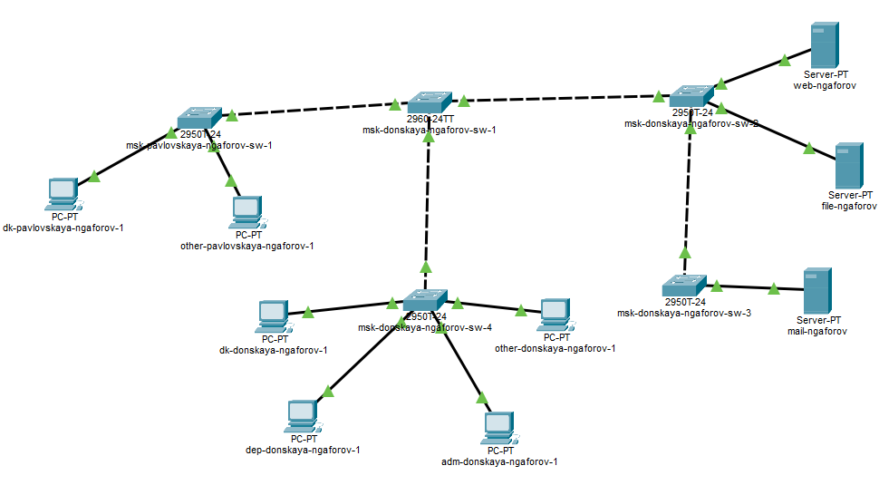

Топология сети L1

## Структура сети

Коммутаторы:

- msk-pavlovskaya-ngaforov-sw-1
- msk-donskaya-ngaforov-sw-1
- msk-donskaya-ngaforov-sw-2
- msk-donskaya-ngaforov-sw-3
- msk-donskaya-ngaforov-sw-4

Серверы:

- web-ngaforov
- file-ngaforov
- mail-ngaforov

# Первоначальная настройка

## Общая последовательность конфигурации

На каждом коммутаторе выполнено:

- Назначение hostname
- Настройка interface vlan 2
- Назначение IP-адреса
- Установка ip default-gateway 10.128.1.1
- Настройка console и vty
- Установка enable secret
- Включение service password-encryption
- Создание пользователя admin
- Назначение доменного имени
- Генерация RSA-ключей
- Включение SSH
- Сохранение конфигурации

## IP-адреса VLAN 2

- sw-1 — 10.128.1.2/24
- sw-2 — 10.128.1.3/24
- sw-3 — 10.128.1.4/24
- sw-4 — 10.128.1.5/24
- pavlovskaya-sw-1 — 10.128.1.6/24

Шлюз по умолчанию: 10.128.1.1

# Настройка коммутаторов

## msk-donskaya-ngaforov-sw-1

- IP: 10.128.1.2/24
- VLAN 2 активирован
- Настроен SSH-доступ
- Конфигурация сохранена

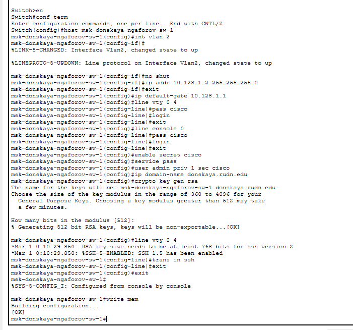

Настройка sw-1

## msk-donskaya-ngaforov-sw-2

- IP: 10.128.1.3/24
- Настроены console и vty
- Создан пользователь admin
- Включено шифрование паролей

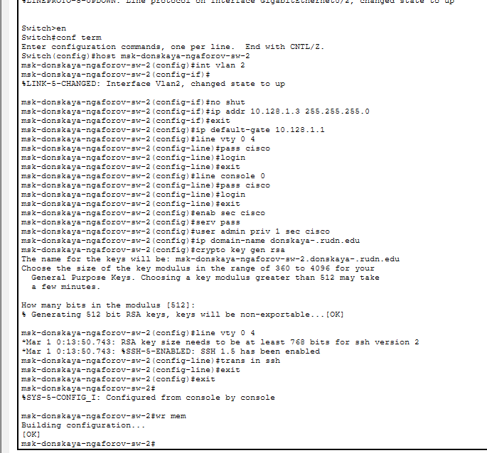

Настройка sw-2

## msk-donskaya-ngaforov-sw-3

- IP: 10.128.1.4/24
- Активирован SSH
- Сохранена конфигурация

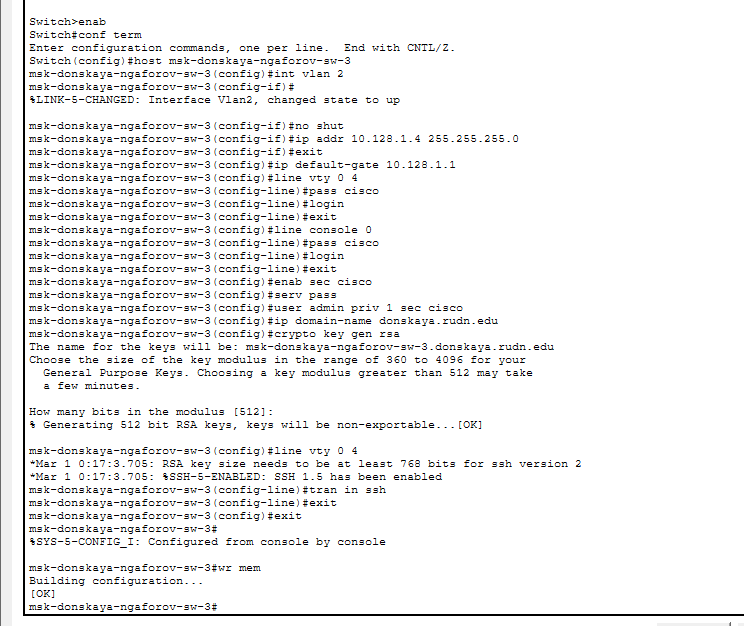

Настройка sw-3

## msk-donskaya-ngaforov-sw-4

- IP: 10.128.1.5/24
- Выполнена базовая настройка безопасности

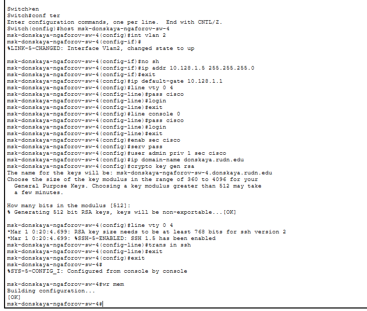

Настройка sw-4

## msk-pavlovskaya-ngaforov-sw-1

- IP: 10.128.1.6/24
- Исправлена синтаксическая ошибка в CLI
- Настроен SSH-доступ
- Конфигурация сохранена

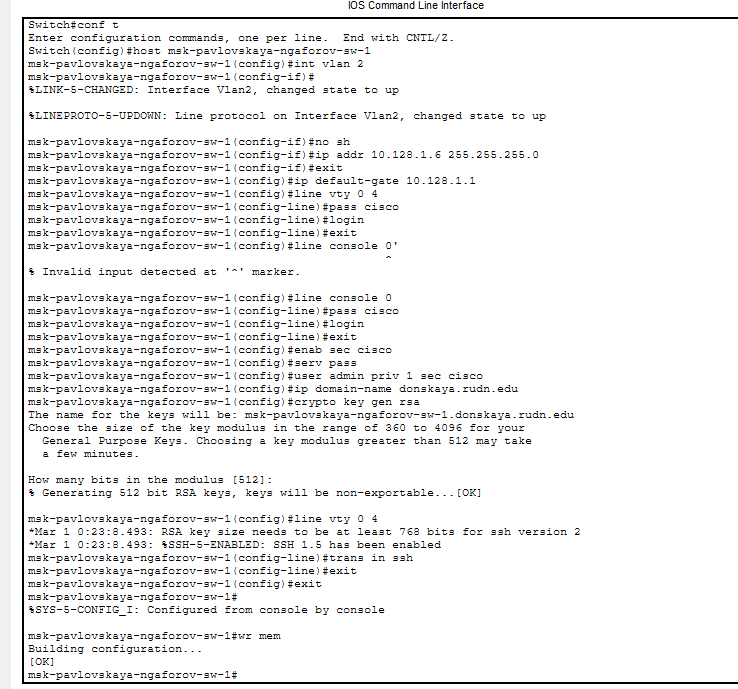

Настройка pavlovskaya-sw-1

# Итог

## Вывод

В ходе работы:

- Построена топология L1
- Настроены интерфейсы управления VLAN 2
- Назначены IP-адреса в сети 10.128.1.0/24
- Настроен удалённый доступ по SSH
- Обеспечена базовая защита доступа
- Конфигурация сохранена во всех коммутаторах